# Assignment_04

SABIHA MHATARNAIK

3/21/2021

```r
library(readr)
library(dplyr)
library(caret)
library(factoextra)
library(tidyverse)
#set the working directory
setwd("~/Desktop/Machine Learning/Assignment /Assignment_04")
```

```r
#Import the dataset
PHARMACEUTICALS <- read.csv("Pharmaceuticals.csv")
```

```r
#Cleaning the data and checking for any null values in each of the column
colSums(is.na(PHARMACEUTICALS)) ## returns the number of null values in each column
```

```
##                Symbol                  Name            Market_Cap
##                     0                     0                     0
##                  Beta              PE_Ratio                   ROE
##                     0                     0                     0
##                   ROA        Asset_Turnover              Leverage
##                     0                     0                     0
##            Rev_Growth     Net_Profit_Margin Median_Recommendation
##                     0                     0                     0
##              Location              Exchange
##                     0                     0
```

```r
#a. Use only the numerical variables (1 to 9) to cluster the 21 firms. Justify the various choices made in
#conducting the cluster analysis, such as weights for different variables, the specific clustering algorithm(s)
#used, the number of clusters formed, and so on.
PHARMACEUTICALS_NUMERIC_VALUES <- PHARMACEUTICALS[,c(3:11)]
```

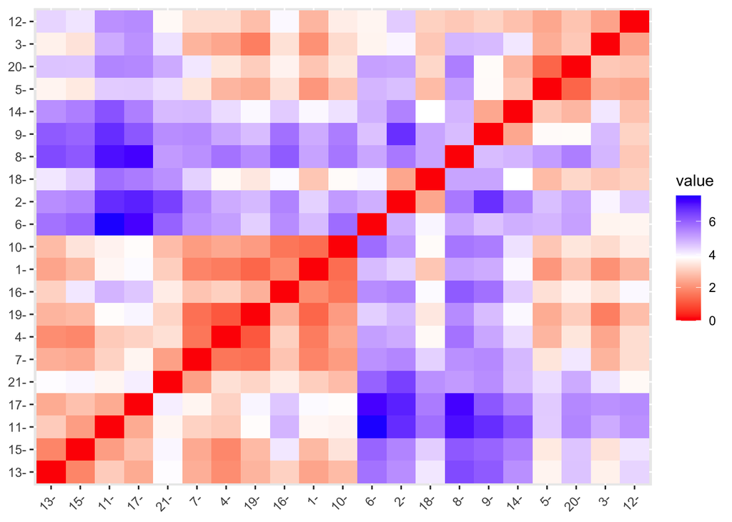

```r
# Scaling quantitative variables in the data frame (z-score)
DATA<- as.data.frame(scale(PHARMACEUTICALS_NUMERIC_VALUES))
distance <- get_dist(DATA)
fviz_dist(distance) # visualizing a distance matrix
```

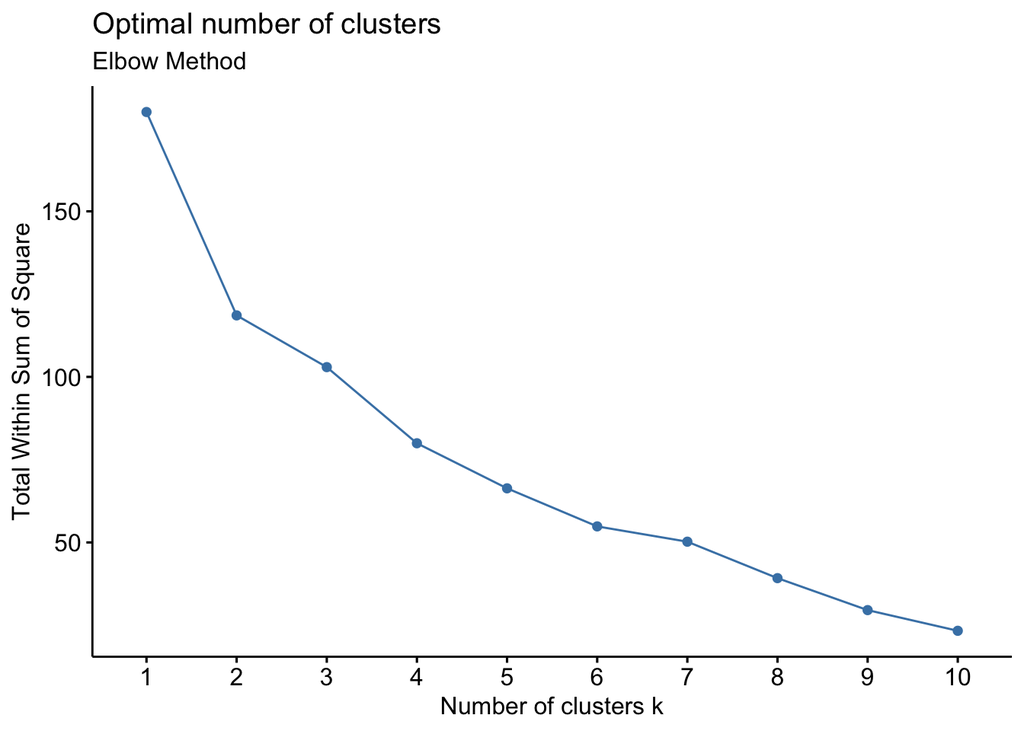

```r
# Estimating the  number of clusters
# Elbow Method on scaled data to determine the value of k
# install.packages("factoextra")

fviz_nbclust(DATA,FUNcluster = kmeans,method = "wss")+labs(subtitle="Elbow Method")
```

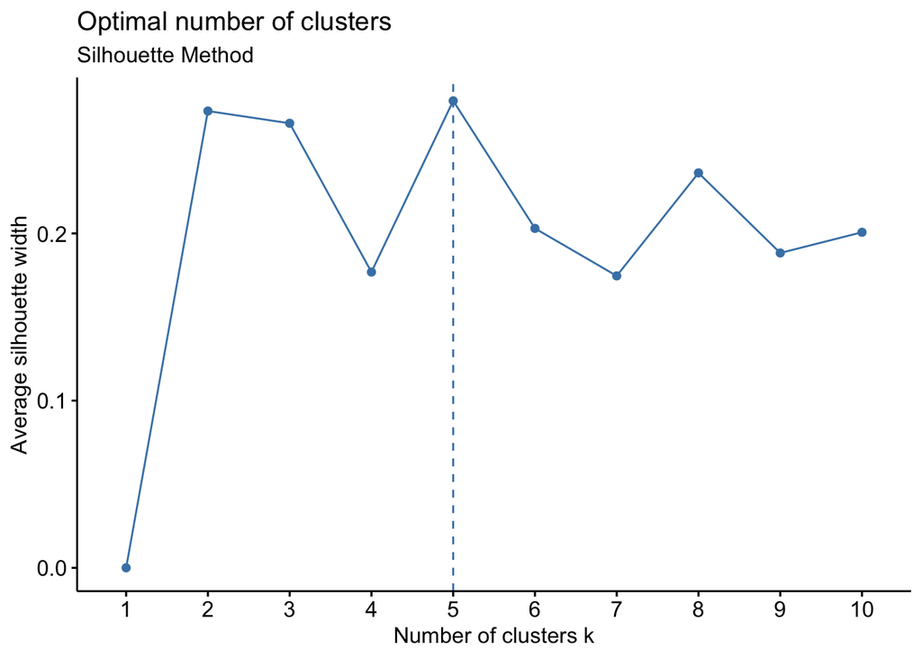

```r
# Silhouette Method on scaled data to determine the number of clusters
fviz_nbclust(DATA,FUNcluster = kmeans,method = "silhouette")+labs(subtitle="Silhouette Method")
```

The plots reveal that 5 clusters are sufficient to capture the data variations

```r
set.seed(1)
K5 <- kmeans(DATA,centers=5,nstart=25) #k=5
K5$centers   #Centroids
```

```
##    Market_Cap       Beta    PE_Ratio        ROE        ROA Asset_Turnover
## 1 -0.76022489  0.2796041 -0.47742380 -0.7438022 -0.8107428     -1.2684804
## 2 -0.43925134 -0.4701800  2.70002464 -0.8349525 -0.9234951      0.2306328
## 3 -0.03142211 -0.4360989 -0.31724852  0.1950459  0.4083915      0.1729746
## 4 -0.87051511  1.3409869 -0.05284434 -0.6184015 -1.1928478     -0.4612656
## 5  1.69558112 -0.1780563 -0.19845823  1.2349879  1.3503431      1.1531640
##      Leverage Rev_Growth Net_Profit_Margin
## 1  0.06308085  1.5180158      -0.006893899
## 2 -0.14170336 -0.1168459      -1.416514761
## 3 -0.27449312 -0.7041516       0.556954446
## 4  1.36644699 -0.6912914      -1.320000179
## 5 -0.46807818  0.4671788       0.591242521
```

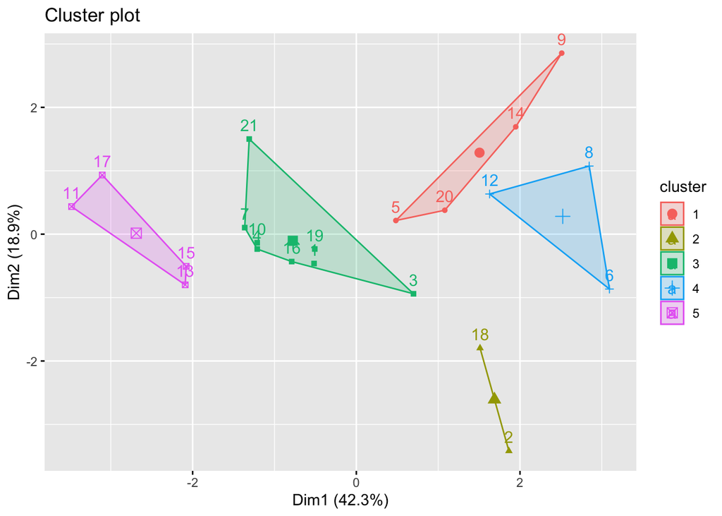

```r
fviz_cluster(K5,data=DATA) #visualize the output
```

```r
#K-Means Cluster Analysis - Fit the data with 5 clusters
fit <- kmeans(DATA, 5)
aggregate(DATA,by=list(fit$cluster),FUN=mean)
```

```
##   Group.1  Market_Cap       Beta   PE_Ratio        ROE        ROA
## 1       1 -0.96247577  1.1949250 -0.3639982 -0.5200697 -0.9610792
## 2       2  0.08926902 -0.4618336 -0.3208615  0.3260892  0.5396003
## 3       3 -0.52462814  0.4451409  1.8498439 -1.0404550 -1.1865838
## 4       4 -0.66114002 -0.7233539 -0.3512251 -0.6736441 -0.5915022
## 5       5  1.69558112 -0.1780563 -0.1984582  1.2349879  1.3503431
##   Asset_Turnover   Leverage Rev_Growth Net_Profit_Margin
## 1  -1.153164e+00  1.4773718  0.7120120        -0.3688236
## 2   6.589509e-02 -0.2559803 -0.7230135         0.7343816
## 3   1.480297e-16 -0.3443544 -0.5769454        -1.6095439
## 4  -1.537552e-01 -0.4040831  0.6917224        -0.4005718
## 5   1.153164e+00 -0.4680782  0.4671788         0.5912425
```

```r
DATA1 <- as.data.frame(DATA, fit$cluster)
DATA1
```

```
##   Market_Cap        Beta    PE_Ratio         ROE        ROA Asset_Turnover
## 2  0.1840960 -0.80125356 -0.04671323  0.04009035  0.2416121      0.0000000
## 3 -0.8544181 -0.45070513  3.49706911 -0.85483986 -0.9422871      0.9225312
## 4 -0.8762600 -0.25595600 -0.29195768 -0.72225761 -0.5100700      0.9225312
## 2  0.1702742 -0.02225704 -0.24290879  0.10638147  0.9181259      0.9225312
## 4 -0.1790256 -0.80125356 -0.32874435 -0.26484883 -0.5664461     -0.4612656
## 3 -0.6953818  2.27578267  0.14948233 -1.45146000 -1.7127612     -0.4612656
## 2 -0.1078688 -0.10015669 -0.70887325  0.59693581  0.8617498      0.9225312
## 1 -0.9767669  1.26308721  0.03299122 -0.11237924 -1.1677918     -0.4612656
## 1 -0.9704532  2.15893320 -1.34037772 -0.70899938 -1.0174553     -1.8450624
## 2  0.2762415 -1.34655112  0.14948233  0.34502953  0.5610770     -0.4612656
## 5  1.0999201 -0.68440408 -0.45749769  2.45971647  1.8389364      1.3837968
## 1 -0.9393967  0.48409069 -0.34100657 -0.29136529 -0.6979905     -0.4612656
## 5  1.9841758 -0.25595600  0.18013789  0.18593083  1.0872544      0.9225312
## 1 -0.9632863  0.87358895  0.19240011 -0.96753478 -0.9610792     -1.8450624
```

[output cut: 29 more lines]

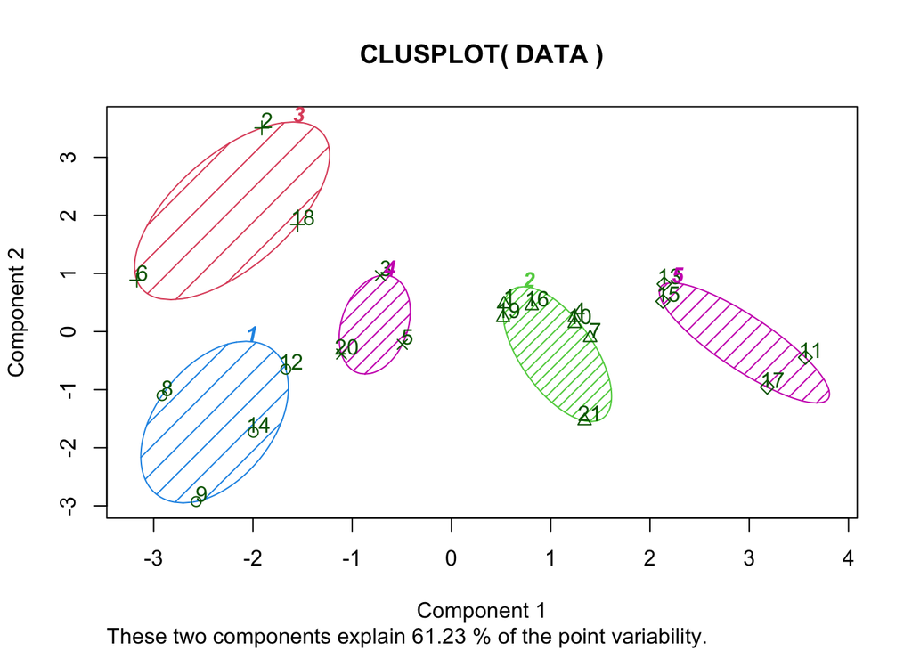

```r
#Visualization Of ClustPlot
library(cluster)
clusplot(DATA ,fit$cluster, color=TRUE, shade=TRUE, labels=2, lines=0)
```

```r
 #(b)Interpret the clusters with respect to the numerical variables used in forming the clusters
```

Cluster 1 - Row 8,9,12,14

Cluster 2 - Row 1,4,7,10,16,19,21

Cluster 3 - Row 2,6,18

Cluster 4 - Row 3,5,20

Cluster 5 - Row 11,13,15,17

By the output of > aggregate(DATA,by=list(fit$cluster),FUN=mean), we can observe the following:

Cluster 1 has lowest Market_Cap,highest Beta,lowest PE_Ratio,highest Leverage,highest Rev_Growth.

Cluster 2 has lowest Rev_Growth,highest Net_Profit_Margin

Cluster 3 has highest PE_Ratio,lowest_ROE,lowest ROA,lowest Net_Profit_Margin

Cluster 5 has highest Market_Cap,highest ROE, highest ROA,highest Asset_Turnover,lowest Leverage.

```r
#(c)Is there a pattern in the clusters with respect to the numerical variables (10 to 12)? (those not used
#in forming the clusters)
```

Cluster 1 with highest Beta ,highest Leverage,highest Rev_Growth has moderate buy Recommendation

Cluster 2 with highest Net_Profit_Margin has in most of the cases hold Recommendation

Cluster 3 with highest PE_Ratio has hold Recommendation.

Cluster 5 with highest Market_Cap,highest ROE, highest ROA,highest Asset_Turnover has equal hold Moderate  
Buy

With respect to media Recommendation Variable ,the clusters follow a particular pattern

Cluster 1 and Cluster 4 has moderate buy Recommendation.

Cluster 2 and Cluster 3 has Hold Recommendation.

```r
#(d)Provide an appropriate name for each cluster using any or all of the variables in the dataset.
```

Cluster 1 - lowest Market_Cap,highest Beta,lowest PE_Ratio,highest Leverage,highest Rev_Growth cluster

Cluster 2 - lowest Rev_Growth,highest Net_Profit_Margin cluster

Cluster 3 - highest PE_Ratio,lowest_ROE,lowest ROA,lowest Net_Profit_Margin cluster

Cluster 5 - highest Market_Cap,highest ROE, highest ROA,highest Asset_Turnover,lowest Leverage cluster